# Soluciones 8

Sergio Camiz

2025-06-05

```r
sum.lm              <- function(lmod) {
summ                <- summary(lmod)
ci                  <- confint(lmod)
summ$coefficients   <- cbind(summ$coefficients[,1],
                             ci,summ$coefficients[,2:4])
summ
}
```

## 1 Construir una carpeta Ejercicio 8

*Hecho*

## 2 Cargar desde Paideia:

```
Iris
```

Decathlon completo datos de pruebas de decathlon, incluyendo la competición y colocarlos en Rstudio como siempre

```r
iris                <- read.csv("Iris.csv",row.names = 1)
dec                 <- read.csv("Decathlon_cpl.csv",row.names = 1)
```

## 3 modelar el puntaje

con X1500m, Discus y Pole.vault y ver cosa cambia incluyendo interacciones con la competición y correndo las tres anova.

```r
lm1                 <- lm(Points~X1500m+Discus+Pole.vault,data=dec)
sum.lm(lm1)
```

```
##
## Call:
## lm(formula = Points ~ X1500m + Discus + Pole.vault, data = dec)
##
## Residuals:
##     Min      1Q  Median      3Q     Max
## -737.94  -87.00   -8.16  144.34  482.91
##
## Coefficients:
##                         2.5 %   97.5 % Std. Error t value Pr(>|t|)
## (Intercept) 6419.133 4116.696 8721.570   1136.337   5.649 1.88e-06 ***
## X1500m       -13.756  -21.282   -6.230      3.714  -3.704  0.00069 ***
## Discus        67.643   42.155   93.131     12.579   5.377 4.37e-06 ***
## Pole.vault   509.436  200.643  818.230    152.401   3.343  0.00191 **
## ---
## Signif. codes:  0 '***' 0.001 '**' 0.01 '*' 0.05 '.' 0.1 ' ' 1
##
## Residual standard error: 252.7 on 37 degrees of freedom
## Multiple R-squared:  0.4959, Adjusted R-squared:  0.4551
## F-statistic: 12.13 on 3 and 37 DF,  p-value: 1.12e-05
```

```r
anova(lm1);Anova(lm1);Anova(lm1,type=3)
```

```
## Analysis of Variance Table
##
## Response: Points
##            Df  Sum Sq Mean Sq F value    Pr(>F)
## X1500m      1  177114  177114  2.7725  0.104342
## Discus      1 1434543 1434543 22.4561 3.152e-05 ***
## Pole.vault  1  713811  713811 11.1739  0.001908 **
## Residuals  37 2363636   63882
## ---
## Signif. codes:  0 '***' 0.001 '**' 0.01 '*' 0.05 '.' 0.1 ' ' 1
```

```
## Anova Table (Type II tests)
##
## Response: Points
##             Sum Sq Df F value    Pr(>F)
## X1500m      876219  1  13.716 0.0006905 ***
## Discus     1847240  1  28.916 4.374e-06 ***
## Pole.vault  713811  1  11.174 0.0019079 **
## Residuals  2363636 37
## ---
## Signif. codes:  0 '***' 0.001 '**' 0.01 '*' 0.05 '.' 0.1 ' ' 1
```

```
## Anova Table (Type III tests)
##
## Response: Points
##              Sum Sq Df F value    Pr(>F)
## (Intercept) 2038531  1  31.911 1.877e-06 ***
## X1500m       876219  1  13.716 0.0006905 ***
## Discus      1847240  1  28.916 4.374e-06 ***
## Pole.vault   713811  1  11.174 0.0019079 **
## Residuals   2363636 37
## ---
## Signif. codes:  0 '***' 0.001 '**' 0.01 '*' 0.05 '.' 0.1 ' ' 1
```

*El modelo sin Competition explica casi el 50% de la varianza total, con todas las pruebas significativas. Las anova II y III confirmen la relevancia de X1500m que sino apareciba no significativa en el anova de tipo I.*

```r
lm2                 <- lm(Points~X1500m*Discus*Pole.vault*Competition,data=dec)
sum.lm(lm2)
```

```
##
## Call:
## lm(formula = Points ~ X1500m * Discus * Pole.vault * Competition,
##     data = dec)
##
## Residuals:
##     Min      1Q  Median      3Q     Max
## -412.41 -128.52   14.98  130.53  438.89
##
## Coefficients:
##                                                              2.5 %     97.5 % Std. Error t value Pr(>|t|)
## (Intercept)                                  -1.374e+06 -4.080e+06  1.333e+06  1.314e+06  -1.045    0.306
## X1500m                                        4.897e+03 -5.004e+03  1.480e+04  4.808e+03   1.019    0.318
## Discus                                        3.073e+04 -3.038e+04  9.185e+04  2.967e+04   1.036    0.310
## Pole.vault                                    2.911e+05 -2.645e+05  8.466e+05  2.698e+05   1.079    0.291
## CompetitionOlympicG                           6.710e+05 -2.274e+06  3.616e+06  1.430e+06   0.469    0.643
## X1500m:Discus                                -1.090e+02 -3.327e+02  1.148e+02  1.086e+02  -1.003    0.325
## X1500m:Pole.vault                            -1.032e+03 -3.062e+03  9.984e+02  9.857e+02  -1.047    0.305
## Discus:Pole.vault                            -6.466e+03 -1.900e+04  6.069e+03  6.086e+03  -1.062    0.298
## X1500m:CompetitionOlympicG                   -2.261e+03 -1.302e+04  8.498e+03  5.224e+03  -0.433    0.669
## Discus:CompetitionOlympicG                   -1.578e+04 -8.195e+04  5.038e+04  3.212e+04  -0.491    0.627
## Pole.vault:CompetitionOlympicG               -1.457e+05 -7.553e+05  4.639e+05  2.960e+05  -0.492    0.627
## X1500m:Discus:Pole.vault                      2.293e+01 -2.291e+01  6.877e+01  2.226e+01   1.030    0.313
## X1500m:Discus:CompetitionOlympicG             5.320e+01 -1.887e+02  2.951e+02  1.174e+02   0.453    0.654
## X1500m:Pole.vault:CompetitionOlympicG         4.894e+02 -1.735e+03  2.714e+03  1.080e+03   0.453    0.654
## Discus:Pole.vault:CompetitionOlympicG         3.437e+03 -1.025e+04  1.712e+04  6.645e+03   0.517    0.610
## X1500m:Discus:Pole.vault:CompetitionOlympicG -1.155e+01 -6.152e+01  3.842e+01  2.426e+01  -0.476    0.638
##
## Residual standard error: 227.6 on 25 degrees of freedom
## Multiple R-squared:  0.7239, Adjusted R-squared:  0.5583
## F-statistic:  4.37 on 15 and 25 DF,  p-value: 0.0005816
```

```r
anova(lm2);Anova(lm2);Anova(lm2,type=3)
```

```
## Analysis of Variance Table
##
## Response: Points
##                                      Df  Sum Sq Mean Sq F value    Pr(>F)
## X1500m                                1  177114  177114  3.4204  0.076253 .
## Discus                                1 1434543 1434543 27.7038 1.888e-05 ***
## Pole.vault                            1  713811  713811 13.7851  0.001032 **
## Competition                           1  134006  134006  2.5879  0.120239
## X1500m:Discus                         1      26      26  0.0005  0.982444
## X1500m:Pole.vault                     1   37781   37781  0.7296  0.401117
## Discus:Pole.vault                     1   11979   11979  0.2313  0.634713
## X1500m:Competition                    1   98269   98269  1.8978  0.180537
## Discus:Competition                    1  190929  190929  3.6872  0.066309 .
## Pole.vault:Competition                1  114739  114739  2.2158  0.149108
## X1500m:Discus:Pole.vault              1  261747  261747  5.0548  0.033619 *
## X1500m:Discus:Competition             1       5       5  0.0001  0.992291
## X1500m:Pole.vault:Competition         1   30357   30357  0.5862  0.451043
## Discus:Pole.vault:Competition         1  177527  177527  3.4284  0.075932 .
## X1500m:Discus:Pole.vault:Competition  1   11736   11736  0.2266  0.638163
## Residuals                            25 1294536   51781
## ---
## Signif. codes:  0 '***' 0.001 '**' 0.01 '*' 0.05 '.' 0.1 ' ' 1
```

```
## Anova Table (Type II tests)
##
## Response: Points
##                                       Sum Sq Df F value    Pr(>F)
## X1500m                               1040157  2 10.0437 0.0006289 ***
## Discus                               1886363  2 18.2147 1.317e-05 ***
## Pole.vault                            898228  2  8.6733 0.0013773 **
## Competition                           614160  4  2.9652 0.0391836 *
## X1500m:Discus                           1875  1  0.0362 0.8506281
## X1500m:Pole.vault                      61828  1  1.1940 0.2849390
## Discus:Pole.vault                      61576  1  1.1891 0.2859019
## X1500m:Competition                    130737  1  2.5248 0.1246385
## Discus:Competition                    393012  1  7.5898 0.0107886 *
## Pole.vault:Competition                 20535  1  0.3966 0.5345788
## X1500m:Discus:Pole.vault              115041  1  2.2217 0.1485957
## X1500m:Discus:Competition              30606  1  0.5911 0.4492136
## X1500m:Pole.vault:Competition          14894  1  0.2876 0.5964866
## Discus:Pole.vault:Competition         177527  1  3.4284 0.0759317 .
## X1500m:Discus:Pole.vault:Competition   11736  1  0.2266 0.6381633
## Residuals                            1294536 25
## ---
## Signif. codes:  0 '***' 0.001 '**' 0.01 '*' 0.05 '.' 0.1 ' ' 1
```

```
## Anova Table (Type III tests)
##
## Response: Points
##                                       Sum Sq Df F value Pr(>F)
## (Intercept)                            56587  1  1.0928 0.3059
## X1500m                                 53723  1  1.0375 0.3182
## Discus                                 55550  1  1.0728 0.3102
## Pole.vault                             60290  1  1.1643 0.2909
## Competition                            11404  1  0.2202 0.6429
## X1500m:Discus                          52089  1  1.0059 0.3255
## X1500m:Pole.vault                      56728  1  1.0955 0.3053
## Discus:Pole.vault                      58448  1  1.1287 0.2982
## X1500m:Competition                      9701  1  0.1874 0.6688
## Discus:Competition                     12501  1  0.2414 0.6275
## Pole.vault:Competition                 12543  1  0.2422 0.6269
## X1500m:Discus:Pole.vault               54937  1  1.0609 0.3129
## X1500m:Discus:Competition              10627  1  0.2052 0.6544
## X1500m:Pole.vault:Competition          10632  1  0.2053 0.6544
## Discus:Pole.vault:Competition          13853  1  0.2675 0.6095
## X1500m:Discus:Pole.vault:Competition   11736  1  0.2266 0.6382
## Residuals                            1294536 25
```

*Corremos una reducción paso a paso para atrás, resultando en el modelo:*

```r
step(lm2,scope = list(upper=lm2,lower=lm1),method="backward")
```

```
## Start:  AIC=456.76
## Points ~ X1500m * Discus * Pole.vault * Competition
##
##                                        Df Sum of Sq     RSS    AIC
## - X1500m:Discus:Pole.vault:Competition  1     11736 1306272 455.13
## <none>                                              1294536 456.76
##
## Step:  AIC=455.13
## Points ~ X1500m + Discus + Pole.vault + Competition + X1500m:Discus +
##     X1500m:Pole.vault + Discus:Pole.vault + X1500m:Competition +
##     Discus:Competition + Pole.vault:Competition + X1500m:Discus:Pole.vault +
##     X1500m:Discus:Competition + X1500m:Pole.vault:Competition +
##     Discus:Pole.vault:Competition
##
##                                        Df Sum of Sq     RSS    AIC
## - X1500m:Pole.vault:Competition         1     14894 1321165 453.60
## - X1500m:Discus:Competition             1     30606 1336877 454.08
## <none>                                              1306272 455.13
## - X1500m:Discus:Pole.vault              1    115041 1421313 456.59
## + X1500m:Discus:Pole.vault:Competition  1     11736 1294536 456.76
## - Discus:Pole.vault:Competition         1    177527 1483799 458.36
##
## Step:  AIC=453.6
## Points ~ X1500m + Discus + Pole.vault + Competition + X1500m:Discus +
##     X1500m:Pole.vault + Discus:Pole.vault + X1500m:Competition +
##     Discus:Competition + Pole.vault:Competition + X1500m:Discus:Pole.vault +
##     X1500m:Discus:Competition + Discus:Pole.vault:Competition
##
##                                 Df Sum of Sq     RSS    AIC
## - X1500m:Discus:Competition      1     44547 1365712 452.96
## <none>                                       1321165 453.60
## - X1500m:Discus:Pole.vault       1    100961 1422127 454.62
## + X1500m:Pole.vault:Competition  1     14894 1306272 455.13
## - Discus:Pole.vault:Competition  1    192990 1514155 457.19
##
## Step:  AIC=452.96
## Points ~ X1500m + Discus + Pole.vault + Competition + X1500m:Discus +
##     X1500m:Pole.vault + Discus:Pole.vault + X1500m:Competition +
##     Discus:Competition + Pole.vault:Competition + X1500m:Discus:Pole.vault +
##     Discus:Pole.vault:Competition
##
##                                 Df Sum of Sq     RSS    AIC
## <none>                                       1365712 452.96
## + X1500m:Discus:Competition      1     44547 1321165 453.60
## + X1500m:Pole.vault:Competition  1     28835 1336877 454.08
## - X1500m:Competition             1    130737 1496449 454.71
## - Discus:Pole.vault:Competition  1    148448 1514160 455.19
## - X1500m:Discus:Pole.vault       1    355022 1720734 460.43
```

```
##
## Call:
## lm(formula = Points ~ X1500m + Discus + Pole.vault + Competition +
##     X1500m:Discus + X1500m:Pole.vault + Discus:Pole.vault + X1500m:Competition +
##     Discus:Competition + Pole.vault:Competition + X1500m:Discus:Pole.vault +
##     Discus:Pole.vault:Competition, data = dec)
##
## Coefficients:
##                           (Intercept)                                 X1500m                                 Discus                             Pole.vault                    CompetitionOlympicG                          X1500m:Discus                      X1500m:Pole.vault
##                            -1.047e+06                              3.720e+03                              2.284e+04                              2.227e+05                              4.531e+04                             -8.049e+01                             -7.855e+02
##                     Discus:Pole.vault             X1500m:CompetitionOlympicG             Discus:CompetitionOlympicG         Pole.vault:CompetitionOlympicG               X1500m:Discus:Pole.vault  Discus:Pole.vault:CompetitionOlympicG
##                            -4.817e+03                             -1.369e+01                             -9.733e+02                             -9.328e+03                              1.698e+01                              2.190e+02
```

```r
lm3                 <- lm(formula = Points ~ X1500m + Discus + Pole.vault +
                          Competition + X1500m:Discus + X1500m:Pole.vault +
                          Discus:Pole.vault + X1500m:Competition +
                          Discus:Competition + Pole.vault:Competition +
                          X1500m:Discus:Pole.vault +
                          Discus:Pole.vault:Competition, data = dec)
sum.lm(lm3)
```

```
##
## Call:
## lm(formula = Points ~ X1500m + Discus + Pole.vault + Competition +
##     X1500m:Discus + X1500m:Pole.vault + Discus:Pole.vault + X1500m:Competition +
##     Discus:Competition + Pole.vault:Competition + X1500m:Discus:Pole.vault +
##     Discus:Pole.vault:Competition, data = dec)
##
## Residuals:
##     Min      1Q  Median      3Q     Max
## -394.60 -121.85   11.14   82.97  443.76
##
## Coefficients:
##                                                       2.5 %     97.5 % Std. Error t value Pr(>|t|)
## (Intercept)                           -1.047e+06 -1.835e+06 -2.598e+05  3.845e+05  -2.724   0.0110 *
## X1500m                                 3.720e+03  9.068e+02  6.533e+03  1.373e+03   2.709   0.0114 *
## Discus                                 2.284e+04  5.735e+03  3.995e+04  8.351e+03   2.735   0.0107 *
## Pole.vault                             2.227e+05  5.596e+04  3.895e+05  8.141e+04   2.736   0.0107 *
## CompetitionOlympicG                    4.531e+04 -8.444e+03  9.907e+04  2.624e+04   1.727   0.0953 .
## X1500m:Discus                         -8.049e+01 -1.416e+02 -1.941e+01  2.982e+01  -2.699   0.0117 *
## X1500m:Pole.vault                     -7.855e+02 -1.380e+03 -1.913e+02  2.901e+02  -2.708   0.0114 *
## Discus:Pole.vault                     -4.817e+03 -8.437e+03 -1.197e+03  1.767e+03  -2.726   0.0109 *
## X1500m:CompetitionOlympicG            -1.369e+01 -3.081e+01  3.438e+00  8.360e+00  -1.637   0.1128
## Discus:CompetitionOlympicG            -9.733e+02 -2.205e+03  2.588e+02  6.015e+02  -1.618   0.1169
## Pole.vault:CompetitionOlympicG        -9.328e+03 -2.057e+04  1.912e+03  5.487e+03  -1.700   0.1002
## X1500m:Discus:Pole.vault               1.698e+01  4.089e+00  2.988e+01  6.296e+00   2.698   0.0117 *
## Discus:Pole.vault:CompetitionOlympicG  2.190e+02 -3.813e+01  4.760e+02  1.255e+02   1.745   0.0920 .
## ---
## Signif. codes:  0 '***' 0.001 '**' 0.01 '*' 0.05 '.' 0.1 ' ' 1
##
## Residual standard error: 220.9 on 28 degrees of freedom
## Multiple R-squared:  0.7087, Adjusted R-squared:  0.5839
## F-statistic: 5.678 on 12 and 28 DF,  p-value: 7.572e-05
```

```r
anova(lm3);Anova(lm3);Anova(lm3,type=3)
```

```
## Analysis of Variance Table
##
## Response: Points
##                               Df  Sum Sq Mean Sq F value    Pr(>F)
## X1500m                         1  177114  177114  3.6312 0.0670208 .
## Discus                         1 1434543 1434543 29.4112 8.732e-06 ***
## Pole.vault                     1  713811  713811 14.6346 0.0006695 ***
## Competition                    1  134006  134006  2.7474 0.1085768
## X1500m:Discus                  1      26      26  0.0005 0.9818920
## X1500m:Pole.vault              1   37781   37781  0.7746 0.3862932
## Discus:Pole.vault              1   11979   11979  0.2456 0.6240577
## X1500m:Competition             1   98269   98269  2.0147 0.1668176
## Discus:Competition             1  190929  190929  3.9145 0.0577862 .
## Pole.vault:Competition         1  114739  114739  2.3524 0.1363130
## X1500m:Discus:Pole.vault       1  261747  261747  5.3664 0.0280657 *
## Discus:Pole.vault:Competition  1  148448  148448  3.0435 0.0920303 .
## Residuals                     28 1365712   48775
## ---
## Signif. codes:  0 '***' 0.001 '**' 0.01 '*' 0.05 '.' 0.1 ' ' 1
```

```
## Anova Table (Type II tests)
##
## Response: Points
##                                Sum Sq Df F value    Pr(>F)
## X1500m                         686689  1 14.0786 0.0008134 ***
## Discus                        1687126  1 34.5897  2.52e-06 ***
## Pole.vault                     746413  1 15.3031 0.0005319 ***
## Competition                    138808  1  2.8459 0.1027215
## X1500m:Discus                     356  1  0.0073 0.9324963
## X1500m:Pole.vault                2906  1  0.0596 0.8089420
## Discus:Pole.vault               45896  1  0.9410 0.3403372
## X1500m:Competition             130737  1  2.6804 0.1127832
## Discus:Competition             385470  1  7.9030 0.0089108 **
## Pole.vault:Competition          20719  1  0.4248 0.5198716
## X1500m:Discus:Pole.vault       355022  1  7.2787 0.0116864 *
## Discus:Pole.vault:Competition  148448  1  3.0435 0.0920303 .
## Residuals                     1365712 28
## ---
## Signif. codes:  0 '***' 0.001 '**' 0.01 '*' 0.05 '.' 0.1 ' ' 1
```

```
## Anova Table (Type III tests)
##
## Response: Points
##                                Sum Sq Df F value  Pr(>F)
## (Intercept)                    361913  1  7.4200 0.01098 *
## X1500m                         357852  1  7.3367 0.01139 *
## Discus                         364893  1  7.4811 0.01070 *
## Pole.vault                     365078  1  7.4849 0.01068 *
## Competition                    145414  1  2.9813 0.09525 .
## X1500m:Discus                  355357  1  7.2856 0.01165 *
## X1500m:Pole.vault              357608  1  7.3317 0.01142 *
## Discus:Pole.vault              362426  1  7.4305 0.01093 *
## X1500m:Competition             130737  1  2.6804 0.11278
## Discus:Competition             127705  1  2.6182 0.11685
## Pole.vault:Competition         140949  1  2.8897 0.10023
## X1500m:Discus:Pole.vault       355022  1  7.2787 0.01169 *
## Discus:Pole.vault:Competition  148448  1  3.0435 0.09203 .
## Residuals                     1365712 28
## ---
## Signif. codes:  0 '***' 0.001 '**' 0.01 '*' 0.05 '.' 0.1 ' ' 1
```

*Reduciendo un poco los regresores, el modelo explica 71% de la varianza y se observa que Competition y su interacciones con las pruebas son muy poco significativas, mientras si son significativas otras interacciones.*

*Hacemos un chequeo final con solo Competition y sus interacciones*

```r
lm4                 <- lm(formula = Points ~ X1500m + Discus + Pole.vault +
                          Competition + X1500m:Competition + Discus:Competition +
                          Pole.vault:Competition, data = dec)
sum.lm(lm4)
```

```
##
## Call:
## lm(formula = Points ~ X1500m + Discus + Pole.vault + Competition +
##     X1500m:Competition + Discus:Competition + Pole.vault:Competition,
##     data = dec)
##
## Residuals:
##     Min      1Q  Median      3Q     Max
## -486.78 -131.56   13.65  173.54  355.93
##
## Coefficients:
##                                                2.5 %     97.5 % Std. Error t value Pr(>|t|)
## (Intercept)                     5.910e+03  2.176e+03  9.643e+03  1.835e+03   3.220  0.00287 **
## X1500m                          7.481e-02 -1.300e+01  1.315e+01  6.426e+00   0.012  0.99078
## Discus                          3.380e+01 -7.305e+00  7.490e+01  2.020e+01   1.673  0.10379
## Pole.vault                      9.952e+01 -5.006e+02  6.997e+02  2.950e+02   0.337  0.73797
## CompetitionOlympicG             3.423e+02 -4.283e+03  4.967e+03  2.273e+03   0.151  0.88124
## X1500m:CompetitionOlympicG     -1.781e+01 -3.344e+01 -2.183e+00  7.682e+00  -2.319  0.02675 *
## Discus:CompetitionOlympicG      4.732e+01 -3.221e+00  9.786e+01  2.484e+01   1.905  0.06554 .
## Pole.vault:CompetitionOlympicG  5.604e+02 -1.257e+02  1.246e+03  3.372e+02   1.662  0.10604
## ---
## Signif. codes:  0 '***' 0.001 '**' 0.01 '*' 0.05 '.' 0.1 ' ' 1
##
## Residual standard error: 235.1 on 33 degrees of freedom
## Multiple R-squared:  0.6111, Adjusted R-squared:  0.5286
## F-statistic: 7.409 on 7 and 33 DF,  p-value: 2.332e-05
```

```r
anova(lm4);Anova(lm4);Anova(lm4,type=3)
```

```
## Analysis of Variance Table
##
## Response: Points
##                        Df  Sum Sq Mean Sq F value    Pr(>F)
## X1500m                  1  177114  177114  3.2053  0.082578 .
## Discus                  1 1434543 1434543 25.9617 1.393e-05 ***
## Pole.vault              1  713811  713811 12.9182  0.001047 **
## Competition             1  134006  134006  2.4252  0.128940
## X1500m:Competition      1  115320  115320  2.0870  0.157985
## Discus:Competition      1  138280  138280  2.5025  0.123202
## Pole.vault:Competition  1  152578  152578  2.7613  0.106043
## Residuals              33 1823452   55256
## ---
## Signif. codes:  0 '***' 0.001 '**' 0.01 '*' 0.05 '.' 0.1 ' ' 1
```

```
## Anova Table (Type II tests)
##
## Response: Points
##                         Sum Sq Df F value    Pr(>F)
## X1500m                  684408  1 12.3861 0.0012856 **
## Discus                 1694637  1 30.6688 3.769e-06 ***
## Pole.vault              754802  1 13.6601 0.0007904 ***
## Competition             134006  1  2.4252 0.1289398
## X1500m:Competition      297082  1  5.3765 0.0267485 *
## Discus:Competition      200497  1  3.6285 0.0655443 .
## Pole.vault:Competition  152578  1  2.7613 0.1060434
## Residuals              1823452 33
## ---
## Signif. codes:  0 '***' 0.001 '**' 0.01 '*' 0.05 '.' 0.1 ' ' 1
```

```
## Anova Table (Type III tests)
##
## Response: Points
##                         Sum Sq Df F value   Pr(>F)
## (Intercept)             573071  1 10.3712 0.002874 **
## X1500m                       7  1  0.0001 0.990782
## Discus                  154651  1  2.7988 0.103790
## Pole.vault                6289  1  0.1138 0.737971
## Competition               1253  1  0.0227 0.881236
## X1500m:Competition      297082  1  5.3765 0.026749 *
## Discus:Competition      200497  1  3.6285 0.065544 .
## Pole.vault:Competition  152578  1  2.7613 0.106043
## Residuals              1823452 33
## ---
## Signif. codes:  0 '***' 0.001 '**' 0.01 '*' 0.05 '.' 0.1 ' ' 1
```

*Sin otras interacciones el modelo solo explica 61% de la varianza. Solo la interacción X1500m:Competition resulta significativa, las otras solo debilmente.*

*Se puede concluir que el puntaje no cambia significativamente debido a la diferencia entre Decastar y Olimpiades, sino que por la estimación del puntaje tienen mayor relevancia las interacciones entre pruebas.*

## 4 correr sobre Iris la misma ANOVA

como en Ejercicio_7 ajuntando los test post-hoc. ¿Que se puede decir bajo los test?

*Aplicamos solo la prueba Student-Neuman-Kuels.*

*### Sepal.length*

```r
lmi1                <- lm(Sepal.length~Species,data=iris)
sum.lm(lmi1)
```

```
##
## Call:
## lm(formula = Sepal.length ~ Species, data = iris)
##
## Residuals:
##     Min      1Q  Median      3Q     Max
## -1.6880 -0.3285 -0.0060  0.3120  1.3120
##
## Coefficients:
##                           2.5 % 97.5 % Std. Error t value Pr(>|t|)
## (Intercept)       5.0060 4.8621 5.1499     0.0728  68.762  < 2e-16 ***
## Speciesversicolor 0.9300 0.7265 1.1335     0.1030   9.033 8.77e-16 ***
## Speciesvirginica  1.5820 1.3785 1.7855     0.1030  15.366  < 2e-16 ***
## ---
## Signif. codes:  0 '***' 0.001 '**' 0.01 '*' 0.05 '.' 0.1 ' ' 1
##
## Residual standard error: 0.5148 on 147 degrees of freedom
## Multiple R-squared:  0.6187, Adjusted R-squared:  0.6135
## F-statistic: 119.3 on 2 and 147 DF,  p-value: < 2.2e-16
```

```r
Anova(lmi1)
```

```
## Anova Table (Type II tests)
##
## Response: Sepal.length
##           Sum Sq  Df F value    Pr(>F)
## Species   63.212   2  119.26 < 2.2e-16 ***
## Residuals 38.956 147
## ---
## Signif. codes:  0 '***' 0.001 '**' 0.01 '*' 0.05 '.' 0.1 ' ' 1
```

```
##
## Study: lmi1 ~ "Species"
##
## Student Newman Keuls Test
## for Sepal.length
##
## Mean Square Error:  0.2650082
##
## Species,  means
##
##            Sepal.length       std  r         se Min Max   Q25 Q50 Q75
## setosa            5.006 0.3524897 50 0.07280222 4.3 5.8 4.800 5.0 5.2
## versicolor        5.936 0.5161711 50 0.07280222 4.9 7.0 5.600 5.9 6.3
## virginica         6.588 0.6358796 50 0.07280222 4.9 7.9 6.225 6.5 6.9
##
## Alpha: 0.05 ; DF Error: 147
##
## Critical Range
##         2         3
## 0.2034688 0.2437727
##
## Means with the same letter are not significantly different.
##
##            Sepal.length groups
## virginica         6.588      a
## versicolor        5.936      b
## setosa            5.006      c
```

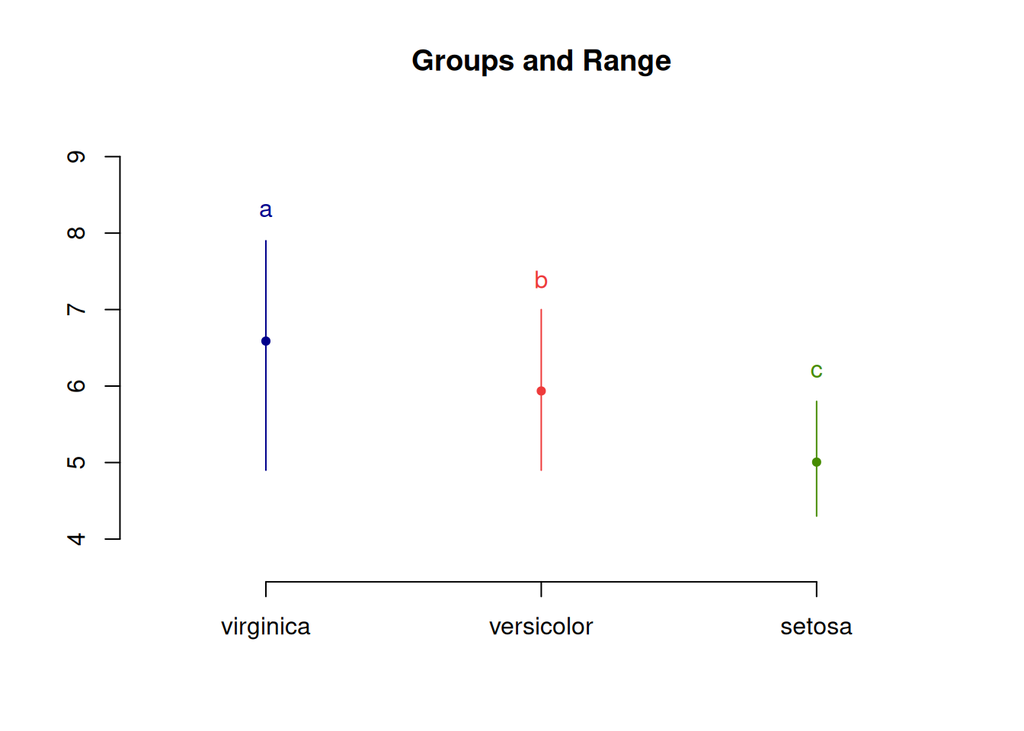

```r
plot(SNK.test(lmi1,"Species",console=TRUE))
```

*### Sepal.width*

```r
lmi2                <- lm(Sepal.width~Species,data=iris)
sum.lm(lmi2)
```

```
##
## Call:
## lm(formula = Sepal.width ~ Species, data = iris)
##
## Residuals:
##    Min     1Q Median     3Q    Max
## -1.128 -0.228  0.026  0.226  0.972
##
## Coefficients:
##                               2.5 %   97.5 % Std. Error t value Pr(>|t|)
## (Intercept)        3.42800  3.33306  3.52294    0.04804  71.359  < 2e-16 ***
## Speciesversicolor -0.65800 -0.79226 -0.52374    0.06794  -9.685  < 2e-16 ***
## Speciesvirginica  -0.45400 -0.58826 -0.31974    0.06794  -6.683 4.54e-10 ***
## ---
## Signif. codes:  0 '***' 0.001 '**' 0.01 '*' 0.05 '.' 0.1 ' ' 1
##
## Residual standard error: 0.3397 on 147 degrees of freedom
## Multiple R-squared:  0.4008, Adjusted R-squared:  0.3926
## F-statistic: 49.16 on 2 and 147 DF,  p-value: < 2.2e-16
```

```r
Anova(lmi2)
```

```
## Anova Table (Type II tests)
##
## Response: Sepal.width
##           Sum Sq  Df F value    Pr(>F)
## Species   11.345   2   49.16 < 2.2e-16 ***
## Residuals 16.962 147
## ---
## Signif. codes:  0 '***' 0.001 '**' 0.01 '*' 0.05 '.' 0.1 ' ' 1
```

```
##
## Study: lmi2 ~ "Species"
##
## Student Newman Keuls Test
## for Sepal.width
##
## Mean Square Error:  0.1153878
##
## Species,  means
##
##            Sepal.width       std  r        se Min Max   Q25 Q50   Q75
## setosa           3.428 0.3790644 50 0.0480391 2.3 4.4 3.200 3.4 3.675
## versicolor       2.770 0.3137983 50 0.0480391 2.0 3.4 2.525 2.8 3.000
## virginica        2.974 0.3224966 50 0.0480391 2.2 3.8 2.800 3.0 3.175
##
## Alpha: 0.05 ; DF Error: 147
##
## Critical Range
##         2         3
## 0.1342604 0.1608553
##
## Means with the same letter are not significantly different.
##
##            Sepal.width groups
## setosa           3.428      a
## virginica        2.974      b
## versicolor       2.770      c
```

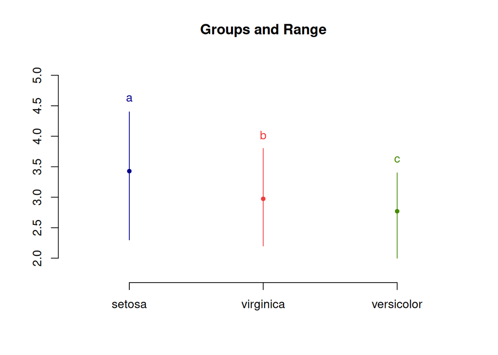

```r
plot(SNK.test(lmi2,"Species",console=TRUE))
```

*### Petal.length*

```r
lmi3                <- lm(Petal.length~Species,data=iris)
sum.lm(lmi3)
```

```
##
## Call:
## lm(formula = Petal.length ~ Species, data = iris)
##
## Residuals:
##    Min     1Q Median     3Q    Max
## -1.260 -0.258  0.038  0.240  1.348
##
## Coefficients:
##                             2.5 %  97.5 % Std. Error t value Pr(>|t|)
## (Intercept)       1.46200 1.34173 1.58227    0.06086   24.02   <2e-16 ***
## Speciesversicolor 2.79800 2.62791 2.96809    0.08607   32.51   <2e-16 ***
## Speciesvirginica  4.09000 3.91991 4.26009    0.08607   47.52   <2e-16 ***
## ---
## Signif. codes:  0 '***' 0.001 '**' 0.01 '*' 0.05 '.' 0.1 ' ' 1
##
## Residual standard error: 0.4303 on 147 degrees of freedom
## Multiple R-squared:  0.9414, Adjusted R-squared:  0.9406
## F-statistic:  1180 on 2 and 147 DF,  p-value: < 2.2e-16
```

```r
Anova(lmi3)
```

```
## Anova Table (Type II tests)
##
## Response: Petal.length
##           Sum Sq  Df F value    Pr(>F)
## Species   437.10   2  1180.2 < 2.2e-16 ***
## Residuals  27.22 147
## ---
## Signif. codes:  0 '***' 0.001 '**' 0.01 '*' 0.05 '.' 0.1 ' ' 1
```

```
##
## Study: lmi3 ~ "Species"
##
## Student Newman Keuls Test
## for Petal.length
##
## Mean Square Error:  0.1851878
##
## Species,  means
##
##            Petal.length       std  r         se Min Max Q25  Q50   Q75
## setosa            1.462 0.1736640 50 0.06085848 1.0 1.9 1.4 1.50 1.575
## versicolor        4.260 0.4699110 50 0.06085848 3.0 5.1 4.0 4.35 4.600
## virginica         5.552 0.5518947 50 0.06085848 4.5 6.9 5.1 5.55 5.875
##
## Alpha: 0.05 ; DF Error: 147
##
## Critical Range
##         2         3
## 0.1700883 0.2037800
##
## Means with the same letter are not significantly different.
##
##            Petal.length groups
## virginica         5.552      a
## versicolor        4.260      b
## setosa            1.462      c
```

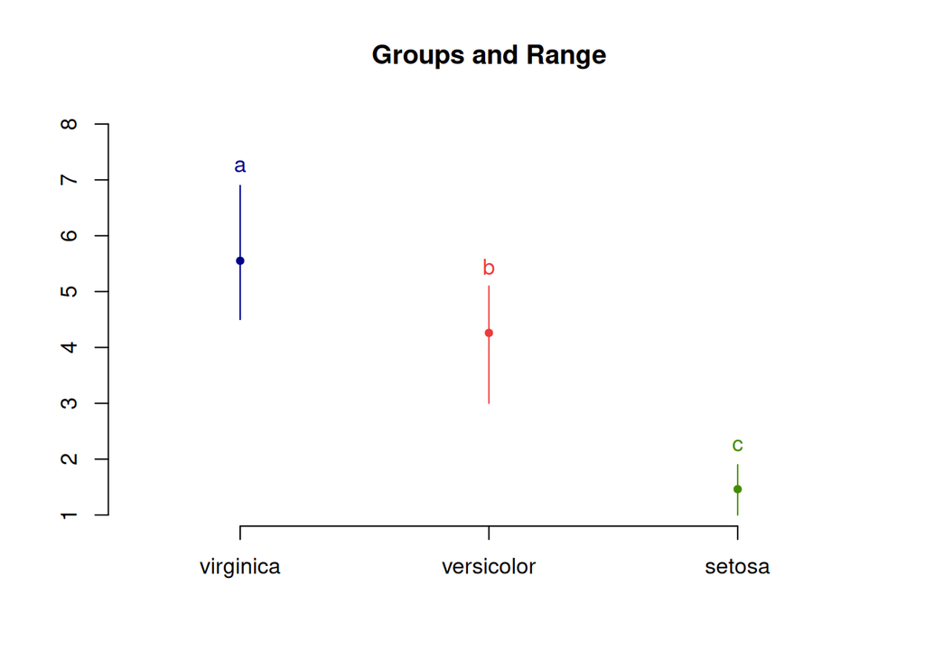

```r
plot(SNK.test(lmi3,"Species",console=TRUE))
```

*### Petal.width*

```r
lmi4                <- lm(Petal.width~Species,data=iris)
sum.lm(lmi4)
```

```
##
## Call:
## lm(formula = Petal.width ~ Species, data = iris)
##
## Residuals:
##    Min     1Q Median     3Q    Max
## -0.626 -0.126 -0.026  0.154  0.474
##
## Coefficients:
##                             2.5 %  97.5 % Std. Error t value Pr(>|t|)
## (Intercept)       0.24600 0.18880 0.30320    0.02894    8.50 1.96e-14 ***
## Speciesversicolor 1.08000 0.99911 1.16089    0.04093   26.39  < 2e-16 ***
## Speciesvirginica  1.78000 1.69911 1.86089    0.04093   43.49  < 2e-16 ***
## ---
## Signif. codes:  0 '***' 0.001 '**' 0.01 '*' 0.05 '.' 0.1 ' ' 1
##
## Residual standard error: 0.2047 on 147 degrees of freedom
## Multiple R-squared:  0.9289, Adjusted R-squared:  0.9279
## F-statistic:   960 on 2 and 147 DF,  p-value: < 2.2e-16
```

```r
Anova(lmi4)
```

```
## Anova Table (Type II tests)
##
## Response: Petal.width
##           Sum Sq  Df F value    Pr(>F)
## Species   80.413   2  960.01 < 2.2e-16 ***
## Residuals  6.157 147
## ---
## Signif. codes:  0 '***' 0.001 '**' 0.01 '*' 0.05 '.' 0.1 ' ' 1
```

```
##
## Study: lmi4 ~ "Species"
##
## Student Newman Keuls Test
## for Petal.width
##
## Mean Square Error:  0.04188163
##
## Species,  means
##
##            Petal.width       std  r         se Min Max Q25 Q50 Q75
## setosa           0.246 0.1053856 50 0.02894188 0.1 0.6 0.2 0.2 0.3
## versicolor       1.326 0.1977527 50 0.02894188 1.0 1.8 1.2 1.3 1.5
## virginica        2.026 0.2746501 50 0.02894188 1.4 2.5 1.8 2.0 2.3
##
## Alpha: 0.05 ; DF Error: 147
##
## Critical Range
##          2          3
## 0.08088724 0.09690970
##
## Means with the same letter are not significantly different.
##
##            Petal.width groups
## virginica        2.026      a
## versicolor       1.326      b
## setosa           0.246      c
```

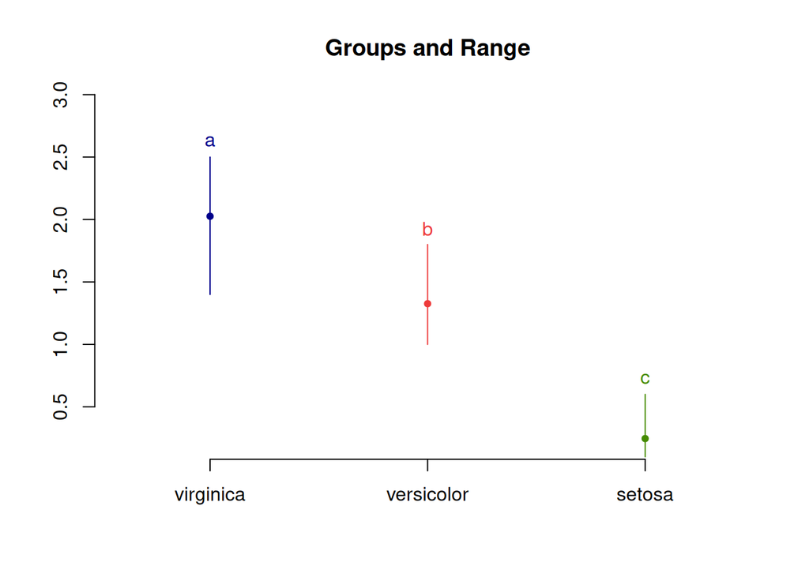

```r
plot(SNK.test(lmi4,"Species",console=TRUE))
```

*En todos los casos los promedios se resultan todos diferentes entre ellos.*

## 5 modelar Petal.length

con las otras variables cuantitativas y la especie y ver que diferencias se encuentran con el análisis de la covarianza.

```r
lmc1                <- lm(Petal.length~.,data=iris)
sum.lm(lmc1)
```

```
##
## Call:
## lm(formula = Petal.length ~ ., data = iris)
##
## Residuals:
##      Min       1Q   Median       3Q      Max
## -0.78396 -0.15708  0.00193  0.14730  0.65418
##
## Coefficients:
##                               2.5 %   97.5 % Std. Error t value Pr(>|t|)
## (Intercept)       -1.11099 -1.64441 -0.57756    0.26987  -4.117 6.45e-05 ***
## Sepal.length       0.60801  0.50869  0.70732    0.05024  12.101  < 2e-16 ***
## Sepal.width       -0.18052 -0.33936 -0.02169    0.08036  -2.246   0.0262 *
## Petal.width        0.60222  0.36218  0.84226    0.12144   4.959 1.97e-06 ***
## Speciesversicolor  1.46337  1.12052  1.80622    0.17345   8.437 3.14e-14 ***
## Speciesvirginica   1.97422  1.49036  2.45809    0.24480   8.065 2.60e-13 ***
## ---
## Signif. codes:  0 '***' 0.001 '**' 0.01 '*' 0.05 '.' 0.1 ' ' 1
##
## Residual standard error: 0.2627 on 144 degrees of freedom
## Multiple R-squared:  0.9786, Adjusted R-squared:  0.9778
## F-statistic:  1317 on 5 and 144 DF,  p-value: < 2.2e-16
```

```r
lmc2                <- lm(Petal.length~Sepal.length*Species+
                          Sepal.width*Species+Petal.width*Species,data=iris)
sum.lm(lmc2)
```

```
##
## Call:
## lm(formula = Petal.length ~ Sepal.length * Species + Sepal.width *
##     Species + Petal.width * Species, data = iris)
##
## Residuals:
##      Min       1Q   Median       3Q      Max
## -0.73253 -0.11246 -0.00635  0.13553  0.58657
##
## Coefficients:
##                                              2.5 %    97.5 % Std. Error t value Pr(>|t|)
## (Intercept)                     0.865467 -0.082515  1.813450   0.479432   1.805   0.0732 .
## Sepal.length                    0.116056 -0.164556  0.396668   0.141917   0.818   0.4149
## Speciesversicolor              -0.700408 -1.934398  0.533581   0.624077  -1.122   0.2637
## Speciesvirginica               -0.400440 -1.624407  0.823526   0.619008  -0.647   0.5188
## Sepal.width                    -0.028654 -0.286378  0.229071   0.130341  -0.220   0.8263
## Petal.width                     0.462527 -0.183882  1.108936   0.326915   1.415   0.1594
## Sepal.length:Speciesversicolor  0.319806 -0.001568  0.641181   0.162532   1.968   0.0511 .
## Sepal.length:Speciesvirginica   0.626916  0.323372  0.930460   0.153514   4.084 7.47e-05 ***
## Speciesversicolor:Sepal.width  -0.078196 -0.465122  0.308730   0.195684  -0.400   0.6901
## Speciesvirginica:Sepal.width   -0.053601 -0.419518  0.312316   0.185059  -0.290   0.7725
## Speciesversicolor:Petal.width   0.897681  0.101340  1.694022   0.402741   2.229   0.0274 *
## Speciesvirginica:Petal.width   -0.246880 -0.952387  0.458627   0.356803  -0.692   0.4901
## ---
## Signif. codes:  0 '***' 0.001 '**' 0.01 '*' 0.05 '.' 0.1 ' ' 1
##
## Residual standard error: 0.2315 on 138 degrees of freedom
## Multiple R-squared:  0.9841, Adjusted R-squared:  0.9828
## F-statistic: 775.4 on 11 and 138 DF,  p-value: < 2.2e-16
```

```r
step(lmc2,scope = list(upper=lmc2,lower=lmc1),method="backward")
```

```
## Start:  AIC=-427.51
## Petal.length ~ Sepal.length * Species + Sepal.width * Species +
##     Petal.width * Species
##
##                        Df Sum of Sq    RSS     AIC
## - Species:Sepal.width   2   0.00927 7.4023 -431.33
## <none>                              7.3931 -427.51
## - Species:Petal.width   2   0.92802 8.3211 -413.78
## - Sepal.length:Species  2   1.16491 8.5580 -409.57
##
## Step:  AIC=-431.33
## Petal.length ~ Sepal.length + Species + Sepal.width + Petal.width +
##     Sepal.length:Species + Species:Petal.width
##
##                        Df Sum of Sq    RSS     AIC
## <none>                              7.4023 -431.33
## + Species:Sepal.width   2   0.00927 7.3931 -427.51
## - Species:Petal.width   2   1.19413 8.5965 -412.89
## - Sepal.length:Species  2   1.51900 8.9213 -407.33
```

```
##
## Call:
## lm(formula = Petal.length ~ Sepal.length + Species + Sepal.width +
##     Petal.width + Sepal.length:Species + Species:Petal.width,
##     data = iris)
##
## Coefficients:
##                    (Intercept)                    Sepal.length               Speciesversicolor                Speciesvirginica                     Sepal.width                     Petal.width  Sepal.length:Speciesversicolor   Sepal.length:Speciesvirginica   Speciesversicolor:Petal.width
##                        0.84262                         0.14875                        -0.70706                        -0.38745                        -0.07004                         0.46676                         0.28191                         0.59216                         0.86208
##   Speciesvirginica:Petal.width
##                       -0.25749
```

```r
lmc3                <- lm(formula = Petal.length ~ Sepal.length + Species +
                          Sepal.width + Petal.width + Sepal.length:Species +
                          Species:Petal.width,data = iris)
sum.lm(lmc3)
```

```
##
## Call:
## lm(formula = Petal.length ~ Sepal.length + Species + Sepal.width +
##     Petal.width + Sepal.length:Species + Species:Petal.width,
##     data = iris)
##
## Residuals:
##      Min       1Q   Median       3Q      Max
## -0.73168 -0.11360 -0.00375  0.13431  0.58502
##
## Coefficients:
##                                            2.5 %   97.5 % Std. Error t value Pr(>|t|)
## (Intercept)                     0.84262 -0.09222  1.77746    0.47285   1.782   0.0769 .
## Sepal.length                    0.14875 -0.07818  0.37568    0.11478   1.296   0.1971
## Speciesversicolor              -0.70706 -1.92069  0.50657    0.61386  -1.152   0.2514
## Speciesvirginica               -0.38745 -1.59508  0.82018    0.61082  -0.634   0.5269
## Sepal.width                    -0.07004 -0.22353  0.08345    0.07764  -0.902   0.3685
## Petal.width                     0.46676 -0.17499  1.10852    0.32460   1.438   0.1527
## Sepal.length:Speciesversicolor  0.28191  0.01871  0.54511    0.13313   2.118   0.0360 *
## Sepal.length:Speciesvirginica   0.59216  0.35296  0.83136    0.12099   4.894 2.68e-06 ***
## Speciesversicolor:Petal.width   0.86208  0.10141  1.62275    0.38475   2.241   0.0266 *
## Speciesvirginica:Petal.width   -0.25749 -0.94775  0.43277    0.34913  -0.738   0.4620
## ---
## Signif. codes:  0 '***' 0.001 '**' 0.01 '*' 0.05 '.' 0.1 ' ' 1
##
## Residual standard error: 0.2299 on 140 degrees of freedom
## Multiple R-squared:  0.9841, Adjusted R-squared:  0.983
## F-statistic: 960.2 on 9 and 140 DF,  p-value: < 2.2e-16
```

```r
Anova(lmc3)
```

```
## Anova Table (Type II tests)
##
## Response: Petal.length
##                      Sum Sq  Df  F value    Pr(>F)
## Sepal.length         9.3787   1 177.3780 < 2.2e-16 ***
## Species              4.9133   2  46.4621 3.341e-16 ***
## Sepal.width          0.0430   1   0.8138    0.3685
## Petal.width          1.0934   1  20.6787 1.165e-05 ***
## Sepal.length:Species 1.5190   2  14.3644 2.117e-06 ***
## Species:Petal.width  1.1941   2  11.2923 2.841e-05 ***
## Residuals            7.4023 140
## ---
## Signif. codes:  0 '***' 0.001 '**' 0.01 '*' 0.05 '.' 0.1 ' ' 1
```

```r
lmc4                <- lm(formula = Petal.length ~ Sepal.length + Species +
                          Petal.width + Sepal.length:Species +
                          Species:Petal.width,data = iris)
sum.lm(lmc4)
```

```
##
## Call:
## lm(formula = Petal.length ~ Sepal.length + Species + Petal.width +
##     Sepal.length:Species + Species:Petal.width, data = iris)
##
## Residuals:
##      Min       1Q   Median       3Q      Max
## -0.72681 -0.11668  0.00073  0.12952  0.57611
##
## Coefficients:
##                                            2.5 %   97.5 % Std. Error t value Pr(>|t|)
## (Intercept)                     0.88128 -0.04904  1.81161    0.47059   1.873  0.06318 .
## Sepal.length                    0.09342 -0.09825  0.28509    0.09695   0.964  0.33693
## Speciesversicolor              -0.80183 -1.99669  0.39302    0.60440  -1.327  0.18677
## Speciesvirginica               -0.48261 -1.67124  0.70602    0.60125  -0.803  0.42351
## Petal.width                     0.45959 -0.18150  1.10069    0.32429   1.417  0.15862
## Sepal.length:Speciesversicolor  0.32734  0.08387  0.57081    0.12315   2.658  0.00877 **
## Sepal.length:Speciesvirginica   0.63569  0.41649  0.85489    0.11088   5.733 5.76e-08 ***
## Speciesversicolor:Petal.width   0.80957  0.05820  1.56094    0.38007   2.130  0.03490 *
## Speciesvirginica:Petal.width   -0.28686 -0.97362  0.39989    0.34738  -0.826  0.41033
## ---
## Signif. codes:  0 '***' 0.001 '**' 0.01 '*' 0.05 '.' 0.1 ' ' 1
##
## Residual standard error: 0.2298 on 141 degrees of freedom
## Multiple R-squared:  0.984,  Adjusted R-squared:  0.9831
## F-statistic:  1082 on 8 and 141 DF,  p-value: < 2.2e-16
```

```r
Anova(lmc4)
```

```
## Anova Table (Type II tests)
##
## Response: Petal.length
##                       Sum Sq  Df F value    Pr(>F)
## Sepal.length          9.4679   1 179.303 < 2.2e-16 ***
## Species              13.6137   2 128.908 < 2.2e-16 ***
## Petal.width           1.2139   1  22.988 4.091e-06 ***
## Sepal.length:Species  1.9024   2  18.013 1.079e-07 ***
## Species:Petal.width   1.1586   2  10.971 3.730e-05 ***
## Residuals             7.4454 141
## ---
## Signif. codes:  0 '***' 0.001 '**' 0.01 '*' 0.05 '.' 0.1 ' ' 1
```

```r
anova(lmc4,lmc3)
```

```
## Analysis of Variance Table
##
## Model 1: Petal.length ~ Sepal.length + Species + Petal.width + Sepal.length:Species +
##     Species:Petal.width
## Model 2: Petal.length ~ Sepal.length + Species + Sepal.width + Petal.width +
##     Sepal.length:Species + Species:Petal.width
##   Res.Df    RSS Df Sum of Sq      F Pr(>F)
## 1    141 7.4454
## 2    140 7.4023  1  0.043031 0.8138 0.3685
```

[figure not shown]

```r
plot(lmc4$fitted.values,iris$Petal.length,typ="n")
  abline(0,1)
  points(lmc4$fitted.values,iris$Petal.length,pch=20,cex=0.4,
         col=c(rep("blue",50),rep("red",50),rep("green",50)))
  legend("bottomright",legend=c("setosa","virginica","versicolor"),
         text.col=c("blue","red","green"))
```

*El modelo que incluye las mediciones y la especie explica 97.86% de la varianza. El método para atrás indica de tirar la interacción sepal.width:species, pero también sepal.width no resulta significativo. Por lo tanto el modelo se limita a considerar las interacciones de Sepal.length y Petal.width con la especie. Se resulta que este modelo explica 98.4% de la varianza. En el gráfico se aprecia el muy bien alineamento de las flores alrededor de la recta óptima, con las tres especies muy bien separadas.*

## 6 comentar los resultados.

*Por falta de tiempo, no pude comentar los resultados. Solo es relevante observar como la identificación de los regresores significativos se resulta mejor con las Anova de tipo II, ya que la de tipo I dependendo del orden no siempre proporciona informaciones útiles.*

## 7 escribir un reporte,

incluyendo los resultados y los gráficos relevantes, comentando los resultados conseguidos.

*Por falta de tiempo, no pude tratar el reporte.*

## 8 guardar los archivos

.Rmd y .html y enviar todos a sergio@camiz.it dentro del 1 de Junio.